# Meta-análise R (2): Analisando Pacotes R como indivíduos em uma rede social

Sillas Teixeira Gonzaga

May 30, 2016

Da [Wikipedia](https://pt.wikipedia.org/wiki/An%C3%A1lise_de_Redes_Sociais):

> As Redes Sociais consistem em estruturas que representam pessoas ou organizações (atores) e as relações entre si. A Análise de Redes Sociais perceciona as relações sociais em termos da Teoria de Redes. Permite estudar, através da identificação dos atores e suas ligações, as relações entre os mesmos de forma a poder identificar as formas de interação entre si, contribuindo para o conhecimento sobre a rede social e o seu desenvolvimento. A Análise de Redes Sociais (ARS) permite representar as redes sociais através da representação dos nós e das ligações entre eles. Os nós da rede social representam os atores dessa rede (indivíduos ou organizações). As ligações representam as relações entre os atores componentes da rede representada.

Não sou nem de longe um especialista nesse tema, mas tenho uma grande curiosidade sobre ele e já li alguns artigos e documentações de pacotes R sobre SNA.

```r
suppressMessages(library(igraph))
suppressMessages(library(miniCRAN))
suppressMessages(library(magrittr))
suppressMessages(library(keyplayer))
suppressMessages(library(dplyr))
library(feather)
suppressMessages(library(visNetwork))
library(knitr)
suppressMessages(library(DT))

#devtools::install_github("wch/webshot")
#webshot::install_phantomjs()
```

Para este post, vou usar, arbitrariamente, os 50 pacotes R mais baixados, que são:

```r
df_pkgs <- read_feather("/home/sillas/R/Projetos/PaixaoPorDados/sillasgonzaga.github.io/data/df_pkgs.feather")
df_pkgs %<>% top_n(50, wt = downloads)
(list_pkgs <- df_pkgs$package)
```

```
##  [1] "RcppArmadillo" "Rcpp"          "ggplot2"       "digest"
##  [5] "stringr"       "plyr"          "stringi"       "magrittr"
##  [9] "scales"        "reshape2"      "RColorBrewer"  "gtable"
## [13] "munsell"       "rgl"           "colorspace"    "labeling"
## [17] "dichromat"     "DBI"           "jsonlite"      "R6"
## [21] "BH"            "zoo"           "mime"          "curl"
## [25] "nlme"          "mixOmics"      "openssl"       "bitops"
## [29] "devtools"      "dplyr"         "car"           "rJava"
## [33] "knitr"         "quantreg"      "evaluate"      "survival"
## [37] "httr"          "htmltools"     "data.table"    "lme4"
## [41] "formatR"       "RCurl"         "chron"         "yaml"
## [45] "foreach"       "caTools"       "Hmisc"         "xtable"
## [49] "highr"         "rmarkdown"
```

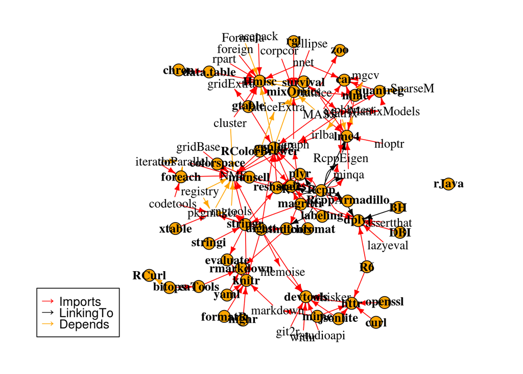

```r
g <- makeDepGraph(list_pkgs, suggests = FALSE)

plot(g, main = "")
```

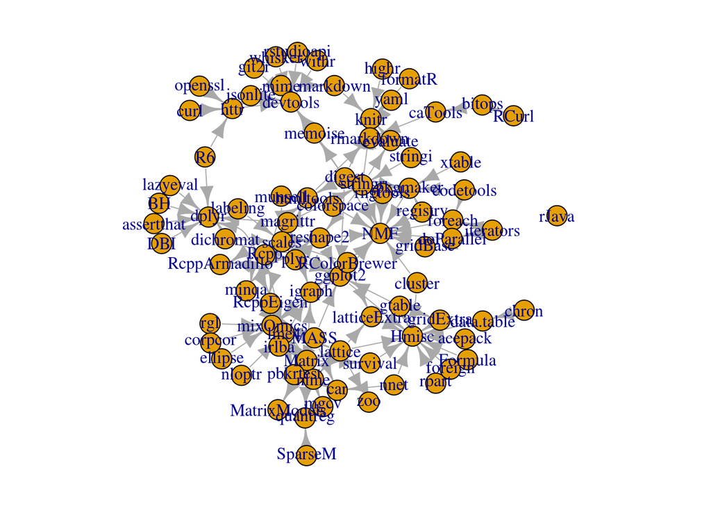

```r
plot.igraph(g, vertex.size=10, layout = layout_with_fr(g))
```

O número de pacotes selecionados para a análise dificultou a leitura da visualização do grafo, mas servirá para analisar diferentes métricas associadas à ARS.

Como homenagem ao Hadley Wickham, os pacotes pertencentes ao Hadleyverse (lista de pacotes R criados ou que tiveram contribuição de Wickham) serão destacados no grafo. O código abaixo foi tirado deste [ótimo artigo](http://adolfoalvarez.cl/the-hitchhikers-guide-to-the-hadleyverse/) sobre o Hadleyverse.

```r
# baixar lista de pacotes disponíveis no CRAN
#download.file("http://cran.r-project.org/web/packages/packages.rds", "packages.rds") cerca de 3 MB
rds <- readRDS(file="packages.rds")
data <- as.data.frame(rds, stringsAsFactors = FALSE)

# Limpar os dados
data <- data[,!duplicated(names(data))]
names(data) <- gsub(" ","_", names(data))
names(data) <- gsub("/","_", names(data))
names(data) <- gsub("@","_", names(data))

# Filtrar pacotes do Hadley
hadley <- data %>%
  filter(grepl("Hadley Wickham|Hadley\nWickham", Author)) %>%
  select(Package, Author, Depends, Imports, Suggests, LinkingTo, Enhances)

#Adicionar atributo de grupo aos vértices do grafo
V(g)$group <- ifelse(V(g)$name %in% hadley$Package, "hadleyverse", "no_hadley")
```

Como estou escrevendo para um blog e não para um artigo, acredito que um grafo interativo seja melhor do que um estático. Para plotar uma rede interativa, existe o excelente pacote `visNetwork`. Use o mouse para controlar o grafo abaixo, seja arrastando os vértices ou dando zoom.

```r
visIgraph(g, physics = TRUE, smooth = TRUE, type = "full", randomSeed = 123) %>%
  visOptions(width = "100%", height = "90%",
             highlightNearest = list(enabled = TRUE, degree = 1, hover = TRUE),
             nodesIdSelection = list(enabled = TRUE)) %>%
  visInteraction(hover = TRUE, navigationButtons = TRUE) %>%
  visGroups()
```

[interactive chart not shown]

Outra atividade comumente feita em SNA é calcular diversas métricas de rede. As principais são:

- **Indegree**: Mede quantas pessoas interagem diretamente com o indivíduo;
- **Outdegree**: Mede com quantas pessoas o indivíduo interage diretamente;
- **Closeness**: é a média da distância geodésica entre um dado vértice (ou ponto da rede) e todos os outros vértices que podem ser alcançados a partir do ponto. Ela é uma espécie de menor caminho médio, mas geodésicas dão valores maiores para indivíduos mais centrais. A closeness pode ser dividida em dois tipos: in (que corresponde ao número médio de passo entre um dado vértice para todos os vértices alcanlçáveis na rede) e out(a mesma coisa do in mas com direção contrária);
- **Betweenness**: mede o número de menores caminhos que passam por um dado vértice;
- **Autovetor**: calcula valores maiores para um indivídu que está conectado a outros indivíduos altamente conectados. Por exemplo, um vértice que está conectado com 5 outros vértices bem conectados terá um valor de autovetor maior que um que esteja conectado com cinco vértices de baixa conectividade.

[Fonte](http://lib.stat.cmu.edu/~brian/780/stanford%20social%20network%20labs/04%20Centralities%20and%20Their%20Interrelation/lab_4.R).

Todas as métricas acima podem ser calculadas com o pacote `igraph`.

```r
indegree <- degree(g, mode = "in")
outdegree <- degree(g, mode = "out")
incloseness <- closeness(g, mode = "in") %>% round(6)
outcloseness <- closeness(g, mode = "out") %>% round(6)
betweenness <- betweenness(g) %>% round(1)
eigenvector <- eigen_centrality(g, directed = FALSE) %$% vector %>% round(3)

df_sna <- data.frame(indegree, outdegree, incloseness, outcloseness, betweenness, eigenvector)
# criar tabela interativa com pacote DT
datatable(df_sna)
```

|  | indegree | outdegree | incloseness | outcloseness | betweenness | eigenvector |
| --- | --- | --- | --- | --- | --- | --- |
| RcppArmadillo | 2 | 0 | 0.000132 | 0.000131 | 0 | 0.296 |
| Rcpp | 0 | 17 | 0.000131 | 0.000162 | 0 | 1 |
| ggplot2 | 6 | 3 | 0.000157 | 0.000137 | 36.5 | 0.374 |
| digest | 0 | 8 | 0.000131 | 0.000151 | 0 | 0.222 |
| stringr | 2 | 6 | 0.000134 | 0.000149 | 20 | 0.204 |
| plyr | 2 | 3 | 0.000132 | 0.000142 | 1 | 0.497 |
| stringi | 0 | 1 | 0.000131 | 0.000151 | 0 | 0.03 |
| magrittr | 0 | 3 | 0.000131 | 0.000153 | 0 | 0.099 |
| scales | 7 | 1 | 0.000142 | 0.000138 | 19.5 | 0.477 |
| reshape2 | 4 | 2 | 0.000138 | 0.000138 | 11 | 0.504 |

[output cut: 78 more lines]

# Conclusões:

Com a tabela acima, podemos ter alguns aprendizados:  
- Os pacotes de maior *indegree* são `NMF` e `Hmisc`, que curiosamente têm *outdegree* baixo. Isso significa que eles importam muitos pacotes mas não são importados por muitos;  
- O pacote `Rcpp` tem os maiores níveis de *outdegree* e *autovetor*, o que mostra sua importância para o desenvolvimento de pacotes R.  
- O fato do `ggplot2` apresentar o maior *betweenness* é curioso. Deixo o significado disso para interpretação do leitor.